# Assignment #5

Ethan Jantz

10/17/2020

This document is made using [R Markdown](https://rmarkdown.rstudio.com/), a great tool for sharing research in a way that is readable and reproducible.

## Assignment 5

Part A:

```
Using an ANOVA, test whether the mean sentiment towards rich people (V162105) and big businesses (V162100) differ as in Part A of Assignment 4.

Next, test whether this difference separately for men and women. Describe whether the difference is the same or different for men and women.
```

Part B:

```
Using the respondent's political party and the continuous dependent variable from Part B of Assignment #4, conduct an ANOVA to test whether democrats and republicans differ on the continuous variable

Next, test whether the difference between republicans and democrats on this variable depends upon if they were voters or nonvoters.
```

```r
knitr::opts_chunk$set(echo = TRUE, message = FALSE, warning = FALSE) # R Markdown options
library(tidyverse); library(gridExtra) # For putting plots side-by-side, trying out a different package this time
library(rmarkdown) # For accessing the functions used to display tables
library(haven) # For reading ANES2016.dta file
library(DescTools) # For LeveneTest()
library(rstatix) # For tukey_hsd()

anes <- haven::read_dta("ANES2016.dta") # Reading in the data
```

# Part A

## Select and Recode Variables

```r
selected <- anes %>%
  select(
    "Rich_People" = V162105,
    "Big_Business" = V162100,
    "Poor_People" = V162099,
    "Party_Reg" = V161019,
    "Voted" = V162031,
    "Gender" = V161342
  ) %>%
  filter(
    Rich_People >= 0, Rich_People <= 100,
    Big_Business >= 0, Big_Business <= 100,
    Poor_People >= 0, Poor_People <= 100,
    Party_Reg == 1 | Party_Reg == 2,
    Voted >= 1, Voted <= 4,
    Gender <= 2, Gender >= 1
  ) %>%
  mutate(
    Rich_People = Rich_People/100,
    Big_Business = Big_Business/100,
    Poor_People = Poor_People/100,
    Party_Reg = factor(Party_Reg, labels = c("Democrat", "Republican")),
    Voted = ifelse(Voted == 4, 1, 0) %>% as.factor(),
    Gender = factor(Gender, labels = c("Male", "Female"))
  )

paged_table(selected)
```

| Rich_People | Big_Business | Poor_People | Party_Reg | Voted | Gender |
| --- | --- | --- | --- | --- | --- |
| 0.50 | 0.70 | 0.70 | Republican | 1 | Male |
| 0.50 | 0.50 | 1.00 | Democrat | 1 | Male |
| 0.85 | 0.40 | 1.00 | Republican | 1 | Female |
| 0.60 | 0.60 | 0.70 | Democrat | 1 | Male |
| 1.00 | 0.70 | 1.00 | Republican | 1 | Male |
| 0.50 | 0.40 | 1.00 | Democrat | 1 | Female |
| 0.90 | 0.40 | 0.50 | Republican | 1 | Female |
| 0.15 | 0.15 | 0.85 | Republican | 1 | Female |
| 0.70 | 0.60 | 0.60 | Democrat | 1 | Female |
| 0.85 | 0.85 | 1.00 | Democrat | 1 | Male |

[output cut: 1221 more lines]

## Testing Differences in Mean Between Two Variables Using ANOVA

```r
sentiment_model <- aov(selected$Rich_People ~ selected$Big_Business)

summary(sentiment_model)
```

```
##                         Df Sum Sq Mean Sq F value Pr(>F)
## selected$Big_Business    1  12.00  11.996   381.6 <2e-16 ***
## Residuals             1229  38.63   0.031
## ---
## Signif. codes:  0 '***' 0.001 '**' 0.01 '*' 0.05 '.' 0.1 ' ' 1
```

```r
# For comparison
wilcox.test(selected$Rich_People, selected$Big_Business, paired = TRUE)
```

```
##
##  Wilcoxon signed rank test with continuity correction
##
## data:  selected$Rich_People and selected$Big_Business
## V = 301414, p-value < 2.2e-16
## alternative hypothesis: true location shift is not equal to 0
```

> **Answer** The p-value for the ANOVA of the two variables and the Wilcoxon Test of the two variables is equal and significant (p < .001). This means that the means of the two variables, Rich_People (0.5535743) and Big_Business (0.4990171), are significantly different from each other.

## Testing Differences in Mean Sentiment by Gender

```r
rich_gender_model <- aov(selected$Rich_People ~ selected$Gender)

business_gender_model <- aov(selected$Big_Business ~ selected$Gender)

summary(rich_gender_model)
```

```
##                   Df Sum Sq Mean Sq F value Pr(>F)
## selected$Gender    1   0.04 0.03528   0.857  0.355
## Residuals       1229  50.59 0.04117
```

```r
summary(business_gender_model)
```

```
##                   Df Sum Sq Mean Sq F value   Pr(>F)
## selected$Gender    1   0.56  0.5588   11.38 0.000765 ***
## Residuals       1229  60.34  0.0491
## ---
## Signif. codes:  0 '***' 0.001 '**' 0.01 '*' 0.05 '.' 0.1 ' ' 1
```

> **Answer** Based on the resulting p-values, the average sentiment between Male and Female respondents toward Rich People (p = .355) was not significantly different, but the difference was significant in sentiment toward Big Business (p < .001). Let’s try visualizing this:

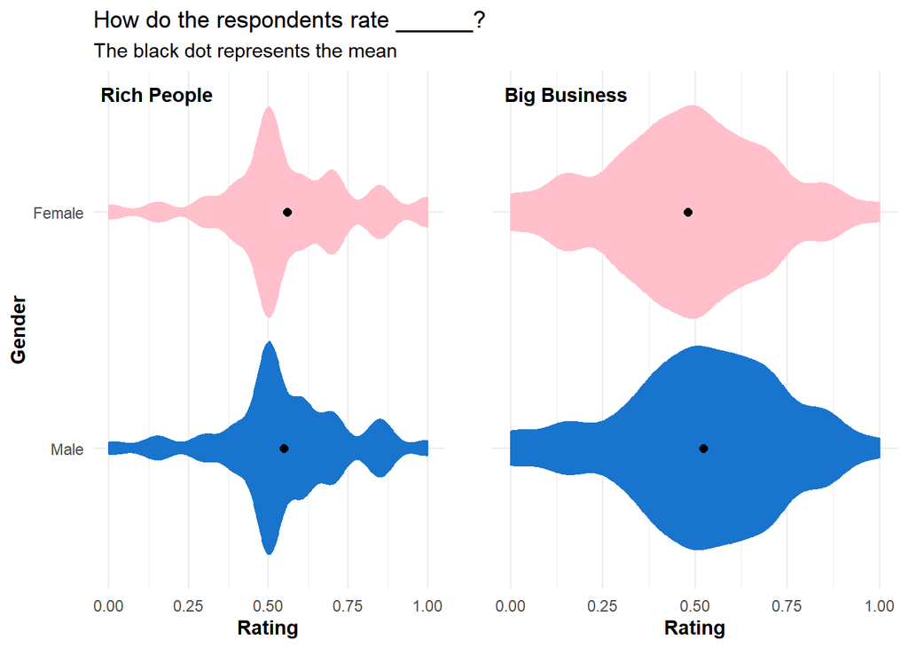

```r
rich_plot <- selected %>%
  ggplot(aes(x = Rich_People,  y = Gender, color = Gender, fill = Gender)) +
  geom_violin() +
  stat_summary(fun.x = mean, geom = "point", size = 2, color = "black") +
  scale_fill_manual(values = c("dodgerblue3", "pink")) +
  scale_color_manual(values = c("dodgerblue3", "pink")) +
  annotate("text", x = .15, y = 2.5, label = "Rich People", fontface = 2) +
  labs(x = "Rating", y = "Gender",
       title = "How do the respondents rate ______?",
       subtitle = "The black dot represents the mean") +
  theme_minimal() +
  theme(axis.title = element_text(face="bold"),
        legend.position = "none")

business_plot <- selected %>%
  ggplot(aes(x = Big_Business,  y = Gender, color = Gender, fill = Gender)) +
  geom_violin() +
  stat_summary(fun.x = mean, geom = "point", size = 2, color = "black") +
  scale_fill_manual(values = c("dodgerblue3", "pink")) +
  scale_color_manual(values = c("dodgerblue3", "pink")) +
  annotate("text", x = .15, y = 2.5, label = "Big Business", fontface = 2) +
  labs(x = "Rating", y = "",
       title = "",
       subtitle = "") +
  theme_minimal() +
  theme(axis.title = element_text(face="bold"), axis.text.y = element_blank(),
        legend.position = "none")

grid.arrange(rich_plot, business_plot, ncol = 2)
```

Here we can see that the means for Rich People between genders is close, and only slightly less so on the means for Big Business. Maybe a table will be more illustrative:

```r
selected %>%
  select(Gender, Big_Business, Rich_People) %>%
  group_by(Gender) %>%
  summarize(Rich_People = mean(Rich_People),
            Big_Business = mean(Big_Business)
            ) %>%
  paged_table()
```

| Gender | Rich_People | Big_Business |
| --- | --- | --- |
| Male | 0.5477143 | 0.5223393 |
| Female | 0.5584650 | 0.4795529 |

Here we can see that there is a very small difference between genders in their mean sentiment toward Rich People (~.01) and a larger difference in their mean sentiment toward Big Business (~.05). Not a huge difference in either case, but we can see why the difference in Big_Business sentiment was significant.

# Part B

## Testing Differences in Mean Sentiment by Party

We’ll be testing the difference in sentiment toward Poor People as done in the previous assignment.

```r
LeveneTest(selected$Poor_People ~ selected$Party_Reg, center = "mean")
```

```
## Levene's Test for Homogeneity of Variance (center = "mean")
##         Df F value Pr(>F)
## group    1  0.0598 0.8068
##       1229
```

```r
LeveneTest(selected$Poor_People ~ selected$Voted, center = "mean")
```

```
## Levene's Test for Homogeneity of Variance (center = "mean")
##         Df F value Pr(>F)
## group    1   2.315 0.1284
##       1229
```

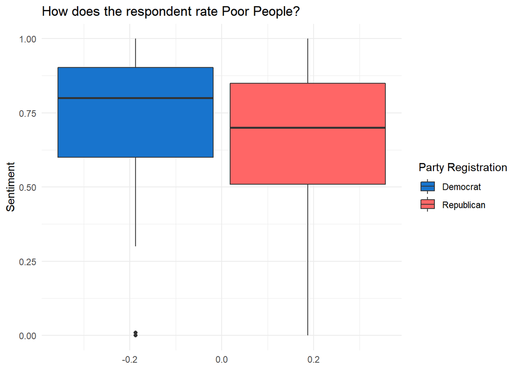

```r
poor_people_byparty <- selected %>%
  select(Party_Reg, Poor_People) %>%
  ggplot(aes(y = Poor_People, fill = Party_Reg)) +
  geom_boxplot() +
  scale_fill_manual(values = c("dodgerblue3", "#ff6666")) +
  theme(axis.text.x = element_blank()) +
  labs(y = "Sentiment", fill = "Party Registration",
       title = "How does the respondent rate Poor People?") +
  theme_minimal()

poor_people_byparty
```

The medians for these box plots look different, and so do the proportions of their quartiles. Let’s run an ANOVA test.

```r
poor_party_model <- aov(selected$Poor_People ~ selected$Party_Reg)

summary(poor_party_model)
```

```
##                      Df Sum Sq Mean Sq F value   Pr(>F)
## selected$Party_Reg    1   1.22  1.2209   35.07 4.12e-09 ***
## Residuals          1229  42.78  0.0348
## ---
## Signif. codes:  0 '***' 0.001 '**' 0.01 '*' 0.05 '.' 0.1 ' ' 1
```

> **Answer** There is a significant difference in average sentiment toward Poor People based on party registration (p < .001) according to these results.

## Testing Party Differences in Mean Sentiment by Whether Respondent Voted

We want to test if grouping respondents by voter/non-voter has a significant effect on the difference in party sentiment toward Poor People. We can start by visualizing the differences. I’ll use box plots.

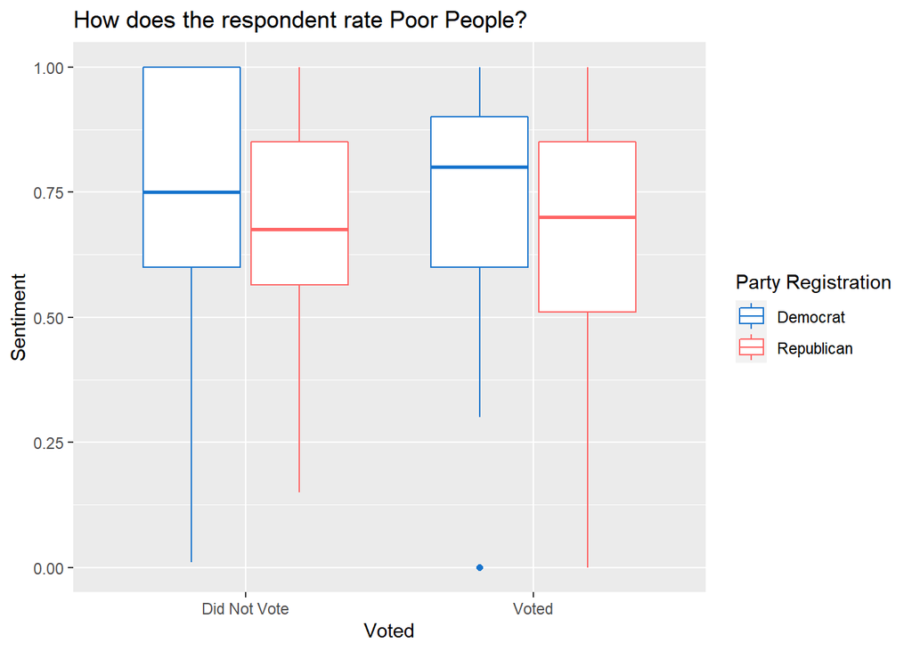

```r
ANOVA_plot <- selected %>%
  select(Poor_People, Party_Reg, Voted) %>%
  ggplot(aes(y = Poor_People, x = Voted, color = Party_Reg)) +
  geom_boxplot() +
  scale_color_manual(values = c("dodgerblue3", "#ff6666")) +
  scale_x_discrete(labels = c("0" = "Did Not Vote", "1" = "Voted")) +
  labs(y = "Sentiment", color = "Party Registration",
       title = "How does the respondent rate Poor People?")


ANOVA_plot
```

Here we can see an interesting difference between voting/non-voting groups between parties. It seems that Non-voting Democrats have a wider sentiment than voters from the same party, and vice versa for Republicans. Let’s test and see if there is a significant difference in the means.

```r
poor_party_twoway_model <- aov(selected$Poor_People ~ selected$Party_Reg * selected$Voted)

summary(poor_party_twoway_model)
```

```
##                                     Df Sum Sq Mean Sq F value   Pr(>F)
## selected$Party_Reg                   1   1.22  1.2209  35.045 4.18e-09 ***
## selected$Voted                       1   0.03  0.0346   0.994    0.319
## selected$Party_Reg:selected$Voted    1   0.00  0.0001   0.003    0.956
## Residuals                         1227  42.75  0.0348
## ---
## Signif. codes:  0 '***' 0.001 '**' 0.01 '*' 0.05 '.' 0.1 ' ' 1
```

The significant difference in party registration is still present, but there doesn’t seem to be significant difference between parties when grouped by whether or not the respondent voted. We can further analyze this with a Tukey HSD test.

```r
poor_model_tukey <- tukey_hsd(poor_party_twoway_model)
poor_model_tukey # Evgenia recommended rstatix::emmeans_test()
```

```
## # A tibble: 8 x 9
##   term  group1 group2 null.value estimate conf.low conf.high   p.adj
## * <chr> <chr>  <chr>       <dbl>    <dbl>    <dbl>     <dbl>   <dbl>
## 1 sele~ Democ~ Repub~          0  -0.0638  -0.0849   -0.0426 4.18e-9
## 2 sele~ 0      1               0   0.0179  -0.0174    0.0533 3.19e-1
## 3 sele~ Democ~ Repub~          0  -0.0616  -0.150     0.0266 2.75e-1
## 4 sele~ Democ~ Democ~          0   0.0189  -0.0445    0.0823 8.69e-1
## 5 sele~ Democ~ Repub~          0  -0.0447  -0.109     0.0197 2.81e-1
## 6 sele~ Repub~ Democ~          0   0.0805   0.0136    0.147  1.08e-2
## 7 sele~ Repub~ Repub~          0   0.0169  -0.0510    0.0848 9.19e-1
## 8 sele~ Democ~ Repub~          0  -0.0636  -0.0928   -0.0344 1.55e-7
## # ... with 1 more variable: p.adj.signif <chr>
```

```r
selected %>%
  group_by(Voted) %>%
  emmeans_test(Poor_People ~ Party_Reg, p.adjust.method = "bonferroni")
```

```
## # A tibble: 2 x 10
##   Voted term   .y.    group1 group2    df statistic       p   p.adj p.adj.signif
## * <chr> <chr>  <chr>  <chr>  <chr>  <dbl>     <dbl>   <dbl>   <dbl> <chr>
## 1 0     Party~ Poor_~ Democ~ Repub~  1227      1.80 7.25e-2 7.25e-2 ns
## 2 1     Party~ Poor_~ Democ~ Repub~  1227      5.60 2.59e-8 2.59e-8 ****
```

The Estimated Marginal Means test backs up the results of the Tukey HSD test, showing that there is not a significant interaction between Voting/Non-voting groups and Party Registration on the respondent’s sentiment toward Poor People.

> **Answer** There is a significant difference between non-voting Republicans and voting Democrats as well as voting Republicans and Democrats according to the Tukey HSD results. Other pairings were not significantly different. From this we can conclude that whether or not a respondent voted did not significantly affect the difference in sentiment between Democrats and Republicans toward Poor People. In otherwords, whether or not a respondent voted does not have a significant interaction effect with their sentiment toward poor people. There are limitations to this report, mainly that I did not code for Independent/Other registered parties amont respondents. Respondents that register Democrat/Republican are more likely to vote than registered Independents, and this bias may have affected the results of my tests.